# Quiz 230329

coop711

2023-03-29

## Red, Black을 잘못 표시한 사람들

| 학번 | 랜덤화출석부 | 구글예습퀴즈 |
| --- | --- | --- |
| 20234132 | Red | Black |
| 20183802 | Red | Black |
| 20222413 | Red | Black |
| 20222760 | Red | Black |
| 20203007 | Black | Red |
| 20203041 | Red | Black |
| 20203329 | Red | Black |
| 20233254 | Red | Black |
| 20183716 | Red | Black |
| 20221531 | Black | Red |
| 20235127 | Black | Red |
| 20221073 | Black | Red |
| 20207034 | Black | Red |
| 20196617 | Black | Red |
| 20221607 | Red | Black |
| 20236789 | Black | Red |
| 20215114 | Red | Black |
| 20213341 | Red | Black |
| 20181102 | Red | Black |
| 20233001 | Red | Black |
| 20222722 | Red | Black |
| 20221526 | Red | Black |
| 20211604 | Black | Red |
| 20233636 | Red | Black |
| 20203916 | Red | Black |
| 20226176 | Black | Red |
| 20221523 | Red | Black |
| 20206611 | Red | Black |
| 20201506 | Black | Red |
| 20213929 | Red | Black |
| 20226646 | Red | Black |
| 20222638 | Red | Black |
| 20236703 | Black | Red |

|  | Red(구글예습퀴즈) | Black(구글예습퀴즈) |
| --- | --- | --- |
| **Red(랜덤화출석부)** | 429 | 22 |
| **Black(랜덤화출석부)** | 11 | 436 |

# 응답 결과

## Q1. 한글의 문자 유형

### 민주 문자, 엘리트 문자

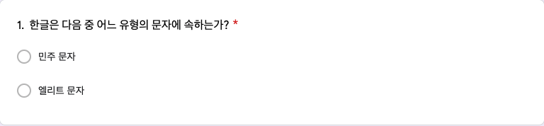

### 한글은 민주 문자

|  | 민주 문자 | 엘리트 문자 | 계 |
| --- | --- | --- | --- |
| **Red** | 404 | 36 | 440 |
| **Black** | 416 | 42 | 458 |
| **계** | 820 | 78 | 898 |

Pearson’s Chi-squared test with simulated p-value (based on 2000 replicates): `.`

| Test statistic | df | P value |
| --- | --- | --- |
| 0.2765 | NA | 0.6297 |

### 한글은 민주 문자(%)

| 민주 문자 | 엘리트 문자 | 계 |
| --- | --- | --- |
| 91.3 | 8.7 | 100.0 |

## Q2. 정보혁명과 문자 체계

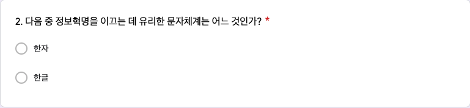

### 정보혁명을 이끄는 문자는 한글(집계표)

|  | 한자 | 한글 | 계 |
| --- | --- | --- | --- |
| **Red** | 55 | 385 | 440 |
| **Black** | 50 | 408 | 458 |
| **계** | 105 | 793 | 898 |

Pearson’s Chi-squared test with simulated p-value (based on 2000 replicates): `.`

| Test statistic | df | P value |
| --- | --- | --- |
| 0.5446 | NA | 0.4793 |

### 정보혁명을 이끄는 문자는 한글(%)

| 한자 | 한글 | 계 |
| --- | --- | --- |
| 11.7 | 88.3 | 100.0 |

## Q3. 알기 힘든 전문 용어

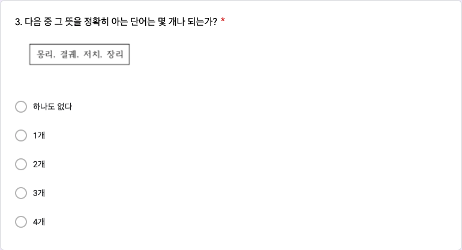

### 몇 개나 아나요?(집계표)

|  | 하나도 없다 | 1개 | 2개 | 3개 | 4개 | 계 |
| --- | --- | --- | --- | --- | --- | --- |
| **Red** | 263 | 92 | 60 | 12 | 13 | 440 |
| **Black** | 266 | 91 | 60 | 22 | 19 | 458 |
| **계** | 529 | 183 | 120 | 34 | 32 | 898 |

Pearson’s Chi-squared test with simulated p-value (based on 2000 replicates): `.`

| Test statistic | df | P value |
| --- | --- | --- |
| 3.729 | NA | 0.4598 |

### 몇 개나 아나요?(%)

| 하나도 없다 | 1개 | 2개 | 3개 | 4개 | 계 |
| --- | --- | --- | --- | --- | --- |
| 58.9 | 20.4 | 13.4 | 3.8 | 3.6 | 100.0 |

## Q4. 해방직후 비문해율

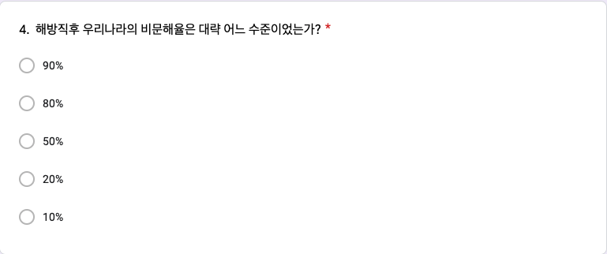

### 집계

|  | 90% | 80% | 50% | 20% | 10% | 계 |
| --- | --- | --- | --- | --- | --- | --- |
| **Red** | 36 | 273 | 69 | 38 | 24 | 440 |
| **Black** | 36 | 277 | 64 | 56 | 25 | 458 |
| **계** | 72 | 550 | 133 | 94 | 49 | 898 |

Pearson’s Chi-squared test with simulated p-value (based on 2000 replicates): `.`

| Test statistic | df | P value |
| --- | --- | --- |
| 3.325 | NA | 0.5022 |

### %

| 90% | 80% | 50% | 20% | 10% | 계 |
| --- | --- | --- | --- | --- | --- |
| 8.0 | 61.2 | 14.8 | 10.5 | 5.5 | 100.0 |

## Q5. 세대간 문해력 격차

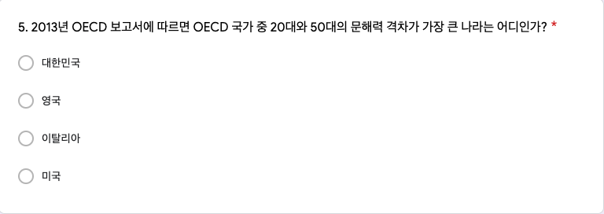

### 집계

|  | 대한민국 | 영국 | 이탈리아 | 미국 | 계 |
| --- | --- | --- | --- | --- | --- |
| **Red** | 307 | 25 | 53 | 55 | 440 |
| **Black** | 315 | 17 | 68 | 58 | 458 |
| **계** | 622 | 42 | 121 | 113 | 898 |

Pearson’s Chi-squared test with simulated p-value (based on 2000 replicates): `.`

| Test statistic | df | P value |
| --- | --- | --- |
| 3.206 | NA | 0.3683 |

### %

| 대한민국 | 영국 | 이탈리아 | 미국 | 계 |
| --- | --- | --- | --- | --- |
| 69.3 | 4.7 | 13.5 | 12.6 | 100.0 |

## Q6. 문해력 격차의 파급효과

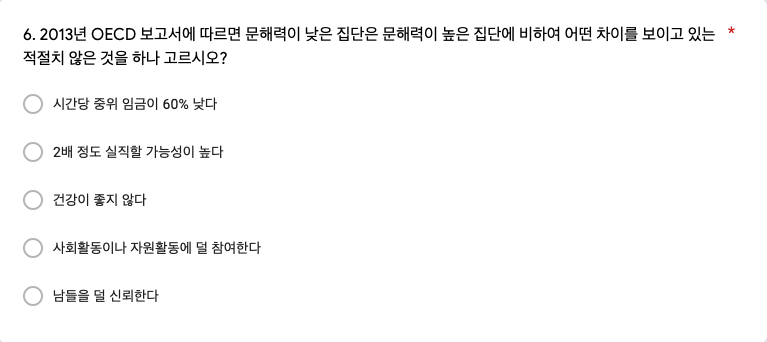

### 집계

|  | 60% 낮은 임금 | 실직 가능성 | 나쁜 건강 | 활동 불참 | 덜 신뢰 | 계 |
| --- | --- | --- | --- | --- | --- | --- |
| **Red** | 197 | 45 | 120 | 33 | 45 | 440 |
| **Black** | 181 | 47 | 143 | 38 | 49 | 458 |
| **계** | 378 | 92 | 263 | 71 | 94 | 898 |

Pearson’s Chi-squared test: `.`

| Test statistic | df | P value |
| --- | --- | --- |
| 2.895 | 4 | 0.5756 |

### %

| 60% 낮은 임금 | 실직 가능성 | 나쁜 건강 | 활동 불참 | 덜 신뢰 | 계 |
| --- | --- | --- | --- | --- | --- |
| 42.1 | 10.2 | 29.3 | 7.9 | 10.5 | 100.0 |

# 一切唯心造(일체유심조)

## Q7. 단어의 영향

## Red

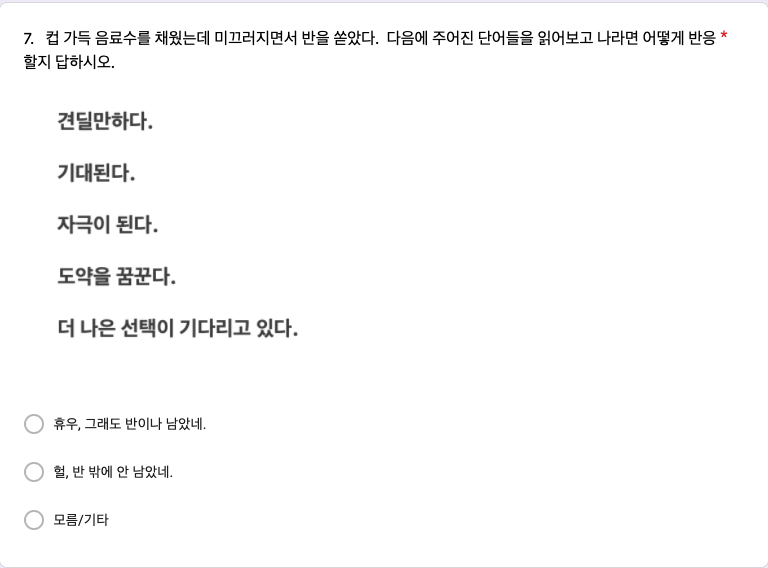

## Black

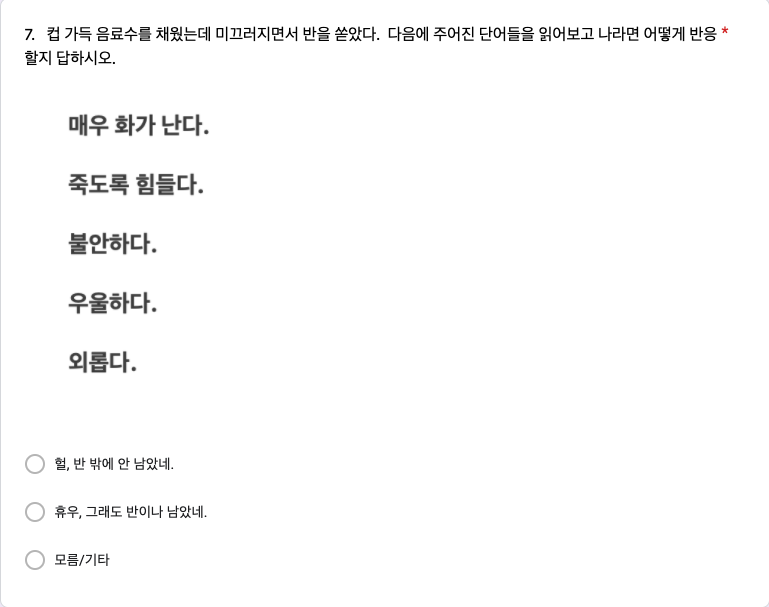

똑같은 상황에서 긍정적인 단어를 보고 답하는 것 (Red)과, 부정적인 단어를 보고 답하는 것(Black)에 따라 Red 집단에는 긍정적 답변의 비율이 높게, Black 집단에는 부정적 답변의 비율이 높게 나올 것으로 기대한 대로 통계적으로 매우 유의한 차이가 관찰됨. 힘든 상황이라도 긍정적인 생각을 가지길~~^^

|  | 반이나 | 반밖에 | 모름/기타 | 계 |
| --- | --- | --- | --- | --- |
| **Red(긍정적 단어)** | 348 | 72 | 20 | 440 |
| **Black(부정적 단어)** | 154 | 273 | 31 | 458 |
| **계** | 502 | 345 | 51 | 898 |

Pearson’s Chi-squared test with simulated p-value (based on 2000 replicates): `.`

| Test statistic | df | P value |
| --- | --- | --- |
| 194.2 | NA | 0.0004998 * * * |

### % 비교.

|  | 반이나 | 반밖에 | 모름/무응답 | 계 |
| --- | --- | --- | --- | --- |
| **Red(긍정적 단어)** | 79.1 | 16.4 | 4.5 | 100.0 |
| **Black(부정적 단어)** | 33.6 | 59.6 | 6.8 | 100.0 |

### % 합계

| 반이나 | 반밖에 | 모름/무응답 | 계 |
| --- | --- | --- | --- |
| 55.9 | 38.4 | 5.7 | 100.0 |

### Mosaic Plot

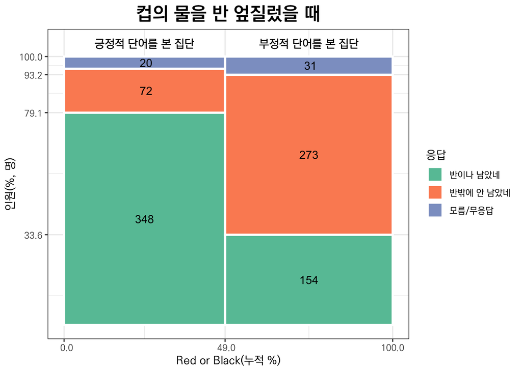

# 제출 시간의 분포

과제 제출이 제출 기간 마지막 날에 몰린다는 것을 시각적으로 보여주고 싶어서 하나 추가하였습니다. 6주차에 접어들어가는 시점에서 마지막 날에 몰리는 현상이 뚜럇해지고 있습니다. 여기서조차 랜덤화 효과를 관찰할 수 있네요. p-value 에 유의해 주세요. 제출시간과 관련한 두 가지 현상에 대해서도 여러분의 생각을 들어보고 싶습니다. 첫째, 랜덤화 효과. 둘쨰, 마감날에 몰리는 현상.

### 일 단위 마감 시간으로부터 제출 시간의 분포

일 단위

|  | [0,1] | (1,2] | (2,3] | (3,4] | (4,5] | (5,6] | (6,7] | (7,8] | (8,9] | (9,10] | (10,11] | (11,12] | (12,13] | (13,14] |
| --- | --- | --- | --- | --- | --- | --- | --- | --- | --- | --- | --- | --- | --- | --- |
| **Red** | 150 | 37 | 34 | 15 | 15 | 22 | 25 | 28 | 27 | 15 | 17 | 15 | 19 | 21 |
| **Black** | 149 | 44 | 17 | 21 | 22 | 19 | 14 | 32 | 22 | 25 | 19 | 22 | 29 | 22 |

Pearson’s Chi-squared test: `.`

| Test statistic | df | P value |
| --- | --- | --- |
| 18.42 | 13 | 0.1421 |

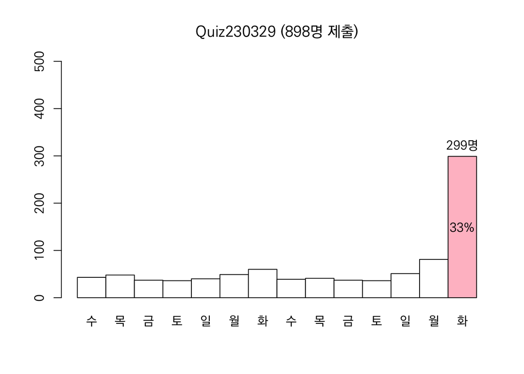